# Data Analysis Comparison

Alex Paynter

7/16/2019

## Introduction

In this document we show the data analysis results using two choices for $C$ grid. The small grid was our pre-specified plan, and we noticed that the $\widehat{C}$ estimates were near the upper bound of the grid for many of the methods. This motivated the use of a larger grid to see if the results were the same.

## Small $C$ grid.

Let $c$ be the maximum observed richness of a sample (maximum over the replciates). In the small $C$ grid simulation we iterate our optimization over $C = \{c, 1.2*c, 1.4*c, \dots, 20*c\}$, or in other words we set a lower bound for the coverage of our sample at 5%. This is the same grid we used in all simulations. After running our algorithm with all methods we find

```
##           2009  2010  2011
## method_0 11200 11440 14014
## method_1  9645 11139 12247
## method_2 10613 11121 11946
## method_3 11200 11440 14014
## method_4 10744 11165 10328
```

Here is a very preliminary plot, with the points slightly horizontally jittered:

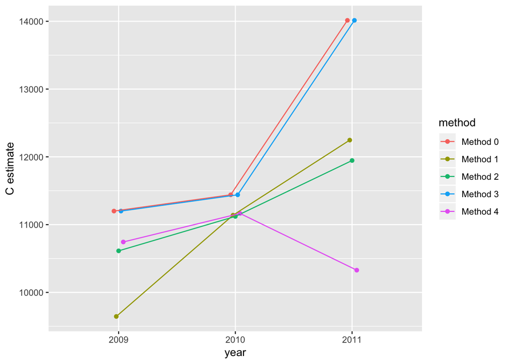

Given that the maximum observed richness in 2009, 2010, 2011 is 560, 572, 715, this caps our $C$ estimates at 11200, 11440, 14300 respecitvely. Therefore we have many estimates which are near the arbitrarily chosen upper bound of our $C$ grid.

## Large $C$ grid

In the large $C$ grid we iterate over $C = \{c, 1.5*c, 2*c, \dots, 50*c\}$, and the results are

```
##           2009  2010  2011
## method_0 27440 28314 33963
## method_1 26197 27166 28524
## method_2 26238 26728 29274
## method_3 27440 28314 33963
## method_4 26862 24034 30554
```

Here is a very preliminary plot, with the points slightly horizontally jittered:

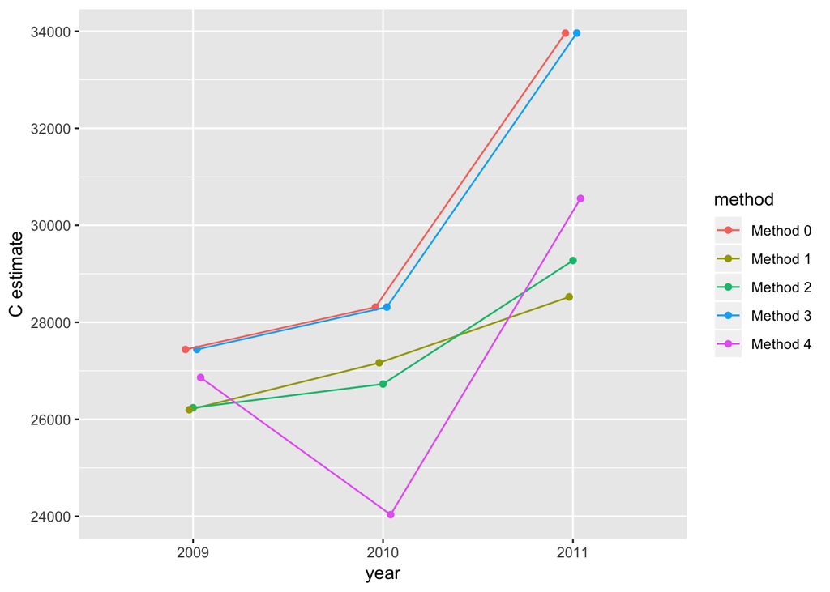

Our results for 2009, 2010, 2011 under this analysis are capped at 28000, 28600, 35750. Unfortunately many of the results are still very close to the upper bound.

## Conclusions

We don’t learn anything new by expanding the $C$ grid. We might learn more by tinkering with the $\lambda^{\text{grid}}$, but I’m inclined to just report the results of the small grid which is what we did in our simulations. We can discuss the difficulty in selecting of $\lambda^{\text{grid}}$ as a limitation.